# Implied Volatility

Kannan Singaravelu

kannan.singaravelu@fitchlearning.com

## Implied Volatility

Implied volatility (IV) is one of the most important parameter in options pricing. IV is determined by the current market price of option contracts on a particular underlying asset. IV is commonly represented as a percentage that indicates the annualized expected one standard deviation range for the underlying asset implied from the option prices.

IV $\sigma_{imp}$ is the volatility value $\sigma$ that makes the Black Scholes value of the option equal to the traded price of the option. In the Black-Scholes model, volatility is the only parameter that can't be directly observed. All other parameters can be determined through market data and this parameter is determined by a numerical optimization technique given the Black-Scholes model.

## Option class

We have created option class in the earlier Python Lab session. We will now append this class to include implied volatility calculation. We will also use `scipy` optimization toolbox to derive the roots of the non-linear equations.

Import required libraries

```python
# Data Manipulation
import pandas as pd
from numpy import *
from datetime import timedelta
import yfinance as yf
from tabulate import tabulate

# Math & Optimization
from scipy.stats import norm
from scipy.optimize import fsolve

# Plotting
import matplotlib.pyplot as plt
from PIL import Image
import cufflinks as cf
cf.set_config_file(offline=True)

# Ignore warnings
import warnings
warnings.filterwarnings('ignore')
```

```python
class BS:

    """
    This is a class for Options contract for pricing European options on stocks/index without dividends.

    Attributes:
        spot          : int or float
        strike        : int or float
        rate          : float
        dte           : int or float [days to expiration in number of years]
        volatility    : float
        callprice     : int or float [default None]
        putprice      : int or float [default None]
    """

    def __init__(self, spot, strike, rate, dte, volatility, callprice=None, putprice=None):

        # Spot Price
        self.spot = spot

        # Option Strike
        self.strike = strike

        # Interest Rate
        self.rate = rate

        # Days To Expiration
        self.dte = dte

        # Volatlity
        self.volatility = volatility

        # Callprice # mkt price
        self.callprice = callprice

        # Putprice # mkt price
        self.putprice = putprice

        # Utility
        self._a_ = self.volatility * self.dte**0.5

        if self.strike == 0:
            raise ZeroDivisionError('The strike price cannot be zero')
        else:
            self._d1_ = (log(self.spot / self.strike) + \
                     (self.rate + (self.volatility**2) / 2) * self.dte) / self._a_

        self._d2_ = self._d1_ - self._a_

        self._b_ = e**-(self.rate * self.dte)


        # The __dict__ attribute
        '''
        Contains all the attributes defined for the object itself. It maps the attribute name to its value.
        '''
        for i in ['callPrice', 'putPrice', 'callDelta', 'putDelta', 'callTheta', 'putTheta', \
                  'callRho', 'putRho', 'vega', 'gamma', 'impvol']:
            self.__dict__[i] = None

        [self.callPrice, self.putPrice] = self._price()
        [self.callDelta, self.putDelta] = self._delta()
        [self.callTheta, self.putTheta] = self._theta()
        [self.callRho, self.putRho] = self._rho()
        self.vega = self._vega()
        self.gamma = self._gamma()
        self.impvol = self._impvol()

    # Option Price
    def _price(self):
        '''Returns the option price: [Call price, Put price]'''

        if self.volatility == 0 or self.dte == 0:
            call = maximum(0.0, self.spot - self.strike)
            put = maximum(0.0, self.strike - self.spot)
        else:
            call = self.spot * norm.cdf(self._d1_) - self.strike * e**(-self.rate * \
                                                                       self.dte) * norm.cdf(self._d2_)

            put = self.strike * e**(-self.rate * self.dte) * norm.cdf(-self._d2_) - \
                                                                        self.spot * norm.cdf(-self._d1_)
        return [call, put]

    # Option Delta
    def _delta(self):
        '''Returns the option delta: [Call delta, Put delta]'''

        if self.volatility == 0 or self.dte == 0:
            call = 1.0 if self.spot > self.strike else 0.0
            put = -1.0 if self.spot < self.strike else 0.0
        else:
            call = norm.cdf(self._d1_)
            put = -norm.cdf(-self._d1_)
        return [call, put]

    # Option Gamma
    def _gamma(self):
        '''Returns the option gamma'''
        return norm.pdf(self._d1_) / (self.spot * self._a_)

    # Option Vega
    def _vega(self):
        '''Returns the option vega'''
        if self.volatility == 0 or self.dte == 0:
            return 0.0
        else:
            return self.spot * norm.pdf(self._d1_) * self.dte**0.5 / 100

    # Option Theta
    def _theta(self):
        '''Returns the option theta: [Call theta, Put theta]'''
        call = -self.spot * norm.pdf(self._d1_) * self.volatility / (2 * self.dte**0.5) - self.rate * self.strike * self._b_ * norm.cdf(self._d2_)

        put = -self.spot * norm.pdf(self._d1_) * self.volatility / (2 * self.dte**0.5) + self.rate * self.strike * self._b_ * norm.cdf(-self._d2_)
        return [call / 365, put / 365]

    # Option Rho
    def _rho(self):
        '''Returns the option rho: [Call rho, Put rho]'''
        call = self.strike * self.dte * self._b_ * norm.cdf(self._d2_) / 100
        put = -self.strike * self.dte * self._b_ * norm.cdf(-self._d2_) / 100

        return [call, put]

    # Option Implied Volatility
    def _impvol(self):
        '''Returns the option implied volatility'''
        if (self.callprice or self.putprice) is None:
            return self.volatility
        else:
            def f(sigma):
                option = BS(self.spot,self.strike,self.rate,self.dte,sigma)
                if self.callprice:
                    return option.callPrice - self.callprice # f(x) = BS_Call - MarketPrice
                if self.putprice and not self.callprice:
                    return option.putPrice - self.putprice

            return maximum(1e-5, fsolve(f, 0.2)[0])
```

```python
# Initialize option
option = BS(100,100,0.02,1,0.2,callprice=10)

header = ['Option Price', 'Delta', 'Gamma', 'Theta', 'Vega', 'Rho', 'IV']
table = [[option.callPrice, option.callDelta, option.gamma, option.callTheta, option.vega, option.callRho, option.impvol]]

print(tabulate(around(table,3),header,tablefmt="grid"))
```

```
+----------------+---------+---------+---------+--------+-------+-------+
|   Option Price |   Delta |   Gamma |   Theta |   Vega |   Rho |    IV |
+================+=========+=========+=========+========+=======+=======+
|          8.916 |   0.579 |    0.02 |  -0.013 |  0.391 |  0.49 | 0.228 |
+----------------+---------+---------+---------+--------+-------+-------+
```

## Implied Volatility Formulation

The Black–Scholes equation describes the price of the option over time as

[figure not shown]

Solving the above equation, we know that the value of a call option for a non-dividend paying stock is:

[figure not shown]

and, the corresponding put option price is:

[figure not shown]

where,

[figure not shown]

and,

[figure not shown]

where,

$S$ is the spot price of the underlying asset  
$K$ is the strike price  
$r$ is the annualized continuous compounded risk free rate  
$\sigma$ is the volatility of returns of the underlying asset  
$t$ is time to maturity (expressed in years)  
$N(x)$ is the standard normal cumulative distribution function

We can look at the call and put equation as a function of the volatility parameter $\sigma$. Finding implied volatility thus requires solving the nonlinear problem $f(x)=0$ where $x=\sigma$ given a starting estimate.

For call options we have,

[figure not shown]

and for puts,

[figure not shown]

To solve the function when $f(x)=0$, numerical precedures like Bisection or Newton's method are employed.

### Newton Method

The Newton-Raphson method uses an iterative procedure to solve for a root using informaiton about the derivative of a function. The first-order derivation $f'$ of the function $f$ represents the tangent line and the approximation to the next value of $x$ is given as

$$ x_1 = x - \frac{f(x)}{f'(x)} $$

The tangent line intersects the $x$ axis and $x_1$ that produces $y=0$. The iterative process is repeated until a maximum iterations are reached or the difference between $x_1$ and $x$ are within acceptable values.

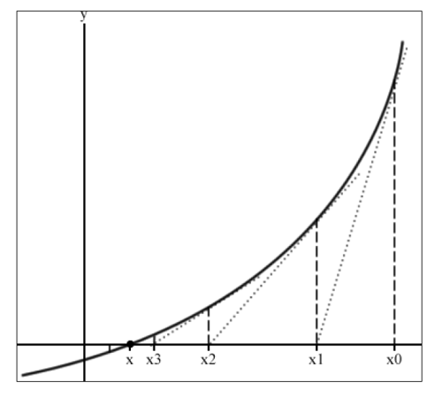

```python
Image.open("newton_tangent_line.PNG").resize((500,450))
```

This method requires to specify initial guess and expect the function to be differentiable. Newton approaches are extremely fast as the rate of convergence is quadractic. The downside to this approach is that it does not guarantee convergence if there are more than one root or when it reaches a local extremum.

```python
def newton_iv(className, spot, strike, rate, dte, volatility, callprice=None, putprice=None):

    x0 = 1 # initial guess
    h = 0.001
    tolerance = 1e-7
    epsilon = 1e-14 # some kind of error or floor

    maxiter = 200

    if callprice:
        # f(x) = Black Scholes Call price - Market Price
        f = lambda x: eval(className)(spot, strike, rate, dte, x).callPrice - callprice
    if putprice:
        f = lambda x: eval(className)(spot, strike, rate, dte, x).putPrice - putprice

    for i in range(maxiter):
        y = f(x0)
        yprime = (f(x0+h) - f(x0-h))/(2*h)      # central difference

        if abs(yprime)<epsilon:
            break                               # this is critial, because volatility cannot be negative
        x1 = x0 - y/yprime

        if (abs(x1-x0) <= tolerance*abs(x1)):
            break
        x0=x1

    return x1
```

```python
opt = BS(100,100,0.02,1,0.2)
```

```python
opt.callPrice
```

```
8.916037278572539
```

```python
newton_iv('BS',100,100,0.02,1,0.2,callprice=8)
```

```
0.17657213831399154
```

```python
newton_iv('BS',100,100,0.02,1,0.2,callprice=8.916037278572539)
```

```
0.20000000000000015
```

```python
newton_iv('BS',100,100,0.02,1,0.2,putprice=10)
```

```
0.27842040930050715
```

### Bisection Method

The bisection method is considered to be one of the simplest and robust root finding algorithm. Suppose, we know the two points of an interval $a$ and $b$, where $a<b$ and $f(a)<0$ and $f(b)>0$ lie along the continuous function and the mid-point of this interval $c = \frac{a+b}{2}$, then we can evaluate the value as $f(c)$.

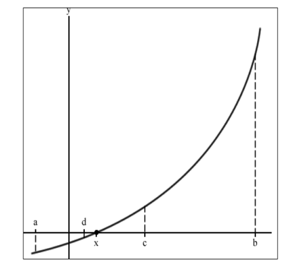

```python
Image.open("bisection_line.PNG").resize((500,450))
```

Iteratively, we replace $c$ as either $a$ or $b$, thereby shortening the interval to find the root. If $f(c) = 0$ or within acceptable value, we have a root. Bisection methods are stable and guarantee to converge. As it does not require knowledge of the derivative, it takes more computational time.

```python
# Bisection Method
def bisection_iv(className, spot, strike, rate, dte, volatility, callprice=None, putprice=None, high=500.0, low=0.0):

    if callprice:
        price = callprice
    if putprice and not callprice:
        price = putprice

    tolerance = 1e-7

    for i in range(1000):
        mid = (high + low) / 2 # c= (a+b)/2
        if mid < tolerance:
            mid = tolerance

        if callprice:
            estimate = eval(className)(spot, strike, rate, dte, mid).callPrice # Blackscholes price
        if putprice:
            estimate = eval(className)(spot, strike, rate, dte, mid).putPrice

        if round(estimate,6) == price:
            break
        elif estimate > price:
            high = mid # b = c
        elif estimate < price:
            low = mid # a = c

    return mid
```

```python
bisection_iv('BS',100,100,0.02,1,0.2,callprice=8)
```

```
0.17657213902566582
```

Take SPX which is non dividend paying and european

## SPX Option

Let's now retrieve SPX option price from Yahoo Finance using `yfinance` library and manipulated the dataframe using the above Black Scholes option pricing model that we created.

https://finance.yahoo.com/quote/^SPX/options?date=1632960000

```python
# Create a ticker object
spx = yf.Ticker('^SPX')
```

```python
# Get Expiry dates
expiry_dates = sorted(spx.options)
expiry_dates[:15]
```

```
['2021-08-31',
 '2021-09-01',
 '2021-09-03',
 '2021-09-07',
 '2021-09-08',
 '2021-09-10',
 '2021-09-13',
 '2021-09-15',
 '2021-09-17',
 '2021-09-20',
 '2021-09-22',
 '2021-09-24',
 '2021-09-27',
 '2021-09-30',
 '2021-10-01']
```

```python
# retrieve from yahoo finance
spx_call = spx.option_chain().calls
spx_puts = spx.option_chain().puts

# save locally
# spx_call.to_csv('data/spx_call.csv')
# spx_puts.to_csv('data/spx_puts.csv')
```

```python
# Filter call option for Sep 2021 Expiry
sep = spx.option_chain('2021-09-30')

# Filter calls for strike above 4535
sep = sep.calls[sep.calls['strike']>4535]
sep.set_index('strike', inplace=True)

# Check the filtered output
sep.iloc[:,:11].head()
```

| strike | contractSymbol | lastTradeDate | lastPrice | bid | ask | change | percentChange | volume | openInterest | impliedVolatility | inTheMoney |
| --- | --- | --- | --- | --- | --- | --- | --- | --- | --- | --- | --- |
| 4540.0 | SPXW210930C04540000 | 2021-08-31 19:40:31 | 45.90 | 47.2 | 47.8 | -6.759998 | -12.837065 | 43.0 | 1132 | 0.106431 | False |
| 4545.0 | SPXW210930C04545000 | 2021-08-31 16:25:35 | 47.38 | 44.4 | 44.8 | 6.380001 | 15.560979 | 1.0 | 309 | 0.104867 | False |
| 4550.0 | SPXW210930C04550000 | 2021-08-31 19:50:54 | 40.80 | 41.6 | 42.0 | -7.000000 | -14.644352 | 674.0 | 3601 | 0.103544 | False |
| 4555.0 | SPXW210930C04555000 | 2021-08-31 19:50:54 | 38.15 | 37.8 | 38.6 | -6.459999 | -14.481055 | 2.0 | 403 | 0.100885 | False |
| 4560.0 | SPXW210930C04560000 | 2021-08-31 16:42:19 | 39.15 | 34.9 | 36.1 | -0.480000 | -1.211202 | 2.0 | 228 | 0.099813 | False |

```python
sep[['bid', 'impliedVolatility']][:4750].iplot(secondary_y='impliedVolatility', mode='lines+markers', size=6,
                                              xTitle='Strike Price', title='Option Call Price Vs Implied Volatility')
```

[interactive chart not shown]

## IV Skew

```python
# Spot prices
spx_spot = 4535
rate = 0.007

# Set valuation and expiry dates
valuation_date = pd.Timestamp('2021-09-01')
expiration_date = pd.Timestamp('2021-09-30')
dte = (expiration_date-valuation_date)/timedelta(365)       # time to maturity in years

# Filter dataframe with ltp
df = sep[['bid', 'ask']]
df['mid'] = 0.5 * (df['bid']+df['ask'])                     # (ask+bid)/2

# Add strike column
df['strike'] = df.index

# Initialize the IV column
df['IV'] = 0.

for i in range(len(df)):
    df['IV'].iloc[i] = 100*BS(spx_spot,
                          df.strike.iloc[i],
                          rate, dte, 0.2,
                          callprice = df.mid.iloc[i]).impvol

df.head()
```

| strike | bid | ask | mid | strike | IV |
| --- | --- | --- | --- | --- | --- |
| 4540.0 | 47.2 | 47.8 | 47.5 | 4540.0 | 9.552827 |
| 4545.0 | 44.4 | 44.8 | 44.6 | 4545.0 | 9.452836 |
| 4550.0 | 41.6 | 42.0 | 41.8 | 4550.0 | 9.355968 |
| 4555.0 | 37.8 | 38.6 | 38.2 | 4555.0 | 9.083699 |
| 4560.0 | 34.9 | 36.1 | 35.5 | 4560.0 | 8.970698 |

```python
df['IV'][:4750].iplot(mode='lines+markers', size=6, xTitle='Strike Price', title=' SEP 2021 Call IV')
```

[interactive chart not shown]

## User Defined Function

```python
def ivskew(spot, rate, value_date, expiry, dataframe):

    valuation_date = pd.Timestamp(value_date)
    expiration_date = pd.Timestamp(expiry)
    dte = (expiration_date-valuation_date)/timedelta(365)

    df = dataframe[['bid', 'ask']]
    df['mid'] = 0.5 * (df['bid']+df['ask'])
    df['strike'] = df.index
    df['IV'] = 0.

    for i in range(len(df)):
        df['IV'].iloc[i] = 100*BS(spot, df.strike.iloc[i], rate, dte, 0.2, callprice = df.mid.iloc[i]).impvol

    return df['IV']
```

```python
# Set expiry list
expiry_list = ['2021-09-17', '2021-09-30']

# Initialise empty dataframe
call_close = pd.DataFrame()
call_vols = pd.DataFrame()

for expiry in expiry_list:

    sub_set = spx.option_chain(expiry).calls
    sub_set = sub_set[(sub_set.strike>4535) & (sub_set.strike<4750)]
    sub_set.set_index('strike', inplace=True)

    call_close[expiry] = sub_set['ask']
    call_vols[expiry] = ivskew(spx_spot, rate, '2021-09-01', expiry, sub_set)
```

```python
# Verify Call IV
# call_vols.index = around(call_vols.index/390,3)
call_vols.iloc[:10]
```

|  | 2021-09-17 | 2021-09-30 |
| --- | --- | --- |
| 4540.0 | 8.133245 | 9.552827 |
| 4545.0 | 7.728370 | 9.541179 |
| 4550.0 | 7.697019 | 9.355968 |
| 4555.0 | 7.846192 | 9.459637 |
| 4560.0 | 8.019702 | 9.329347 |
| 4565.0 | 7.910940 | 9.090277 |
| 4570.0 | 7.717051 | 9.073464 |
| 4575.0 | 7.594474 | 8.936513 |
| 4580.0 | 7.614142 | 8.977182 |
| 4585.0 | 7.399800 | 8.725508 |

## Visualize

```python
call_close.iplot(mode='lines+markers', symbol=['circle-dot', 'square'], size=6,
                 title='Option Call Price', xTitle='strike price')
```

[interactive chart not shown]

```python
call_vols[:4750].iplot(mode='lines+markers', symbol=['circle-dot', 'square'], size=6,
                 title='Expiry-wise IV Skew', xTitle='strike price')
```

[interactive chart not shown]

# References

- [Python Class Reference](https://docs.python.org/3/tutorial/classes.html)
- [Scipy Optimization](https://docs.scipy.org/doc/scipy/reference/generated/scipy.optimize.fsolve.html)
- [Python Resources](https://github.com/kannansingaravelu/PythonResources)

[Kannan Singaravelu](https://github.com/kannansingaravelu)  
Certificate in Quantitative Finance, June 2021